# Habitat size with colonization

#### 2024-09-23

## Pteris mildbraedii

Steps:

- Determine which ecoregions the species occurs in
- Buffer these ecoregions by the buffer distance (currently 112 km)
- Mask all future ranges by this expanded amount to allow colonization outside the ecoregion

#### Full domain model rasters

What do the values mean?

- Subtract 4 from the rasters so that values are -3, -2, -1, 1, 2, 3
- rng >= 2 gives you TP05 within the ecoregion
- abs(rng) >= 2 gives you TP05 over the full domain

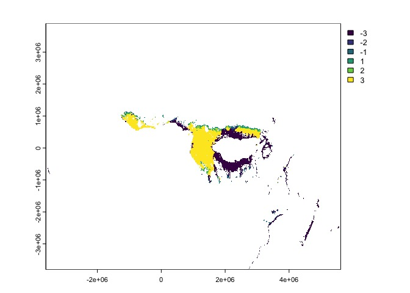

TP05 clipped to ecoregions

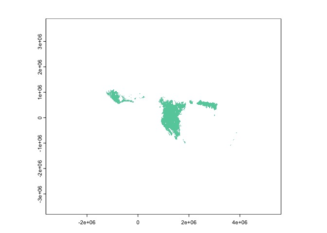

TP05 in the full domain

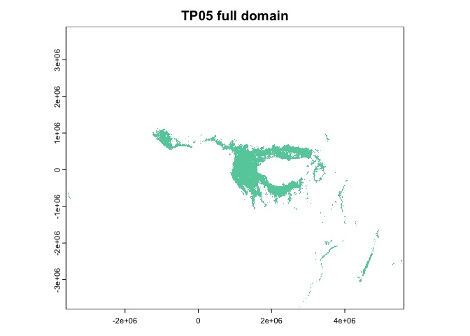

Ecoregions

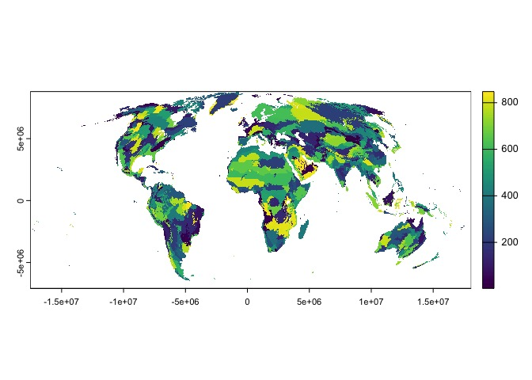

Figure out which eco-regions apply to the range

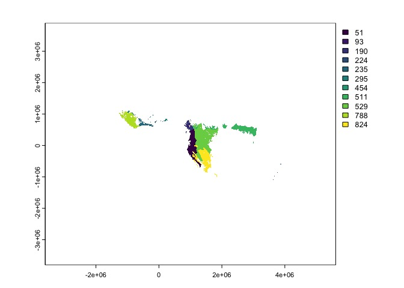

```
 [1]  51  93 190 224 235 295 454 511 529 788 824
```

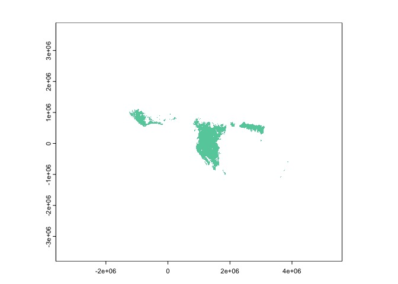

Buffer the ecoregion by 75 years * 1.5 km = 112 km (see notes) and create a mask that will apply to future range projections.

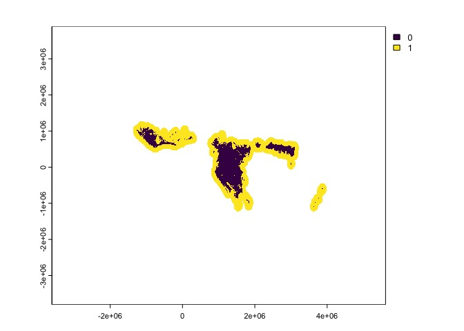

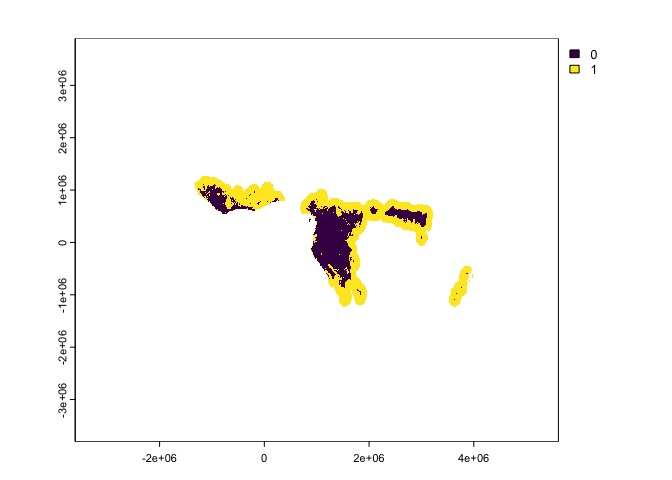

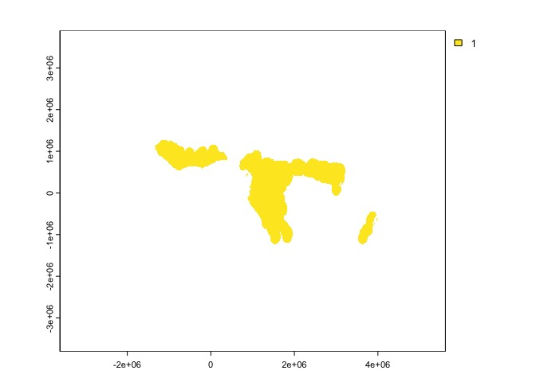

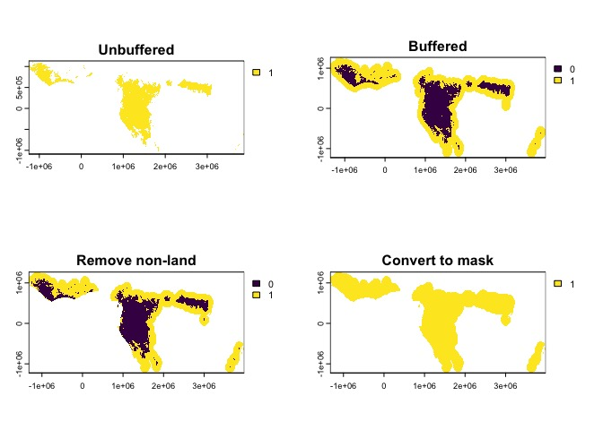

Final range after allowing colonization into the buffered region.

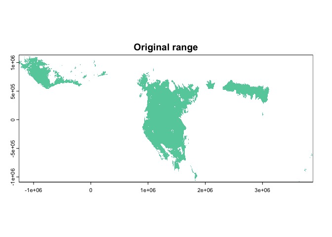

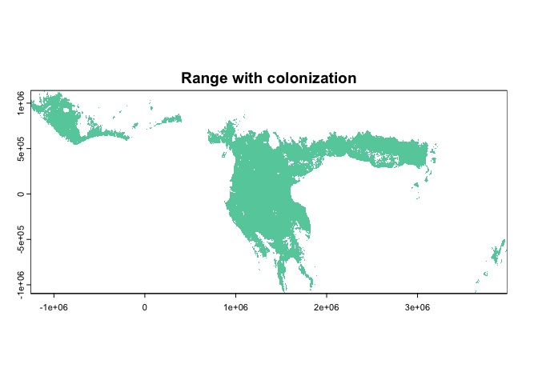

Compare range with colonization (value=1) to original range (value=2).

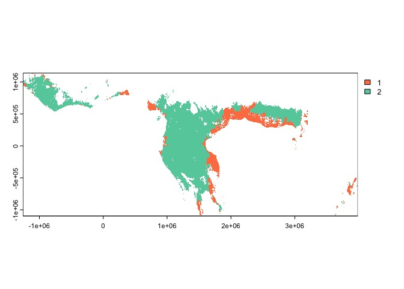

| value | count |
| --- | --- |
| 1 | 10426 |
| 2 | 41570 |

Commit when this report was run: e750ea6

2024-09-23 14:17. America/New_York

3.526 sec elapsed